# 2 From Linear Models to Logistic Regression

# 3 From linear models to logistic regression

In Chapter 1 we introduced the practical problem: our outcome is binary, so the expected value of the outcome is a probability. We also saw the key mathematical move:

$$\text{logit}(p) = \log\left(\frac{p}{1-p}\right),$$

which lets us place probabilities on a scale that can be modelled with a straight line.

This chapter completes the connection with the Linear Regression Short Course. The important change is not only the logistic curve. We also need to replace the normal error model from linear regression with an error model that makes sense for binary data.

- Continue

## 3.1 The linear regression template

In the Linear Regression Short Course, a simple linear model was written as

$$Y_i = \beta_0 + \beta_1 X_i + \varepsilon_i,
\qquad \varepsilon_i \sim N(0, \sigma^2).$$

Equivalently, we can separate the model into two parts:

$$Y_i \sim N(\mu_i, \sigma^2)$$

and

$$\mu_i = E[Y_i] = \beta_0 + \beta_1 X_i.$$

The first line describes how the observed outcomes vary around their mean. The second line describes how the mean changes with the predictor.

**Key-point**

Linear regression has both a **mean model** and an **error model**. The mean model is the straight line. The error model says observations vary around that line with normally distributed errors and constant variance.

In Chapter 1, we focused on the mean model for binary outcomes: how $p_i = E[Y_i]$ might change with $X_i$. We now add the missing error model.

- Continue

## 3.2 The error model for a binary outcome

For Johno’s student example, each outcome is either 1 (pass) or 0 (fail):

$$Y_i =
\begin{cases}
1 & \text{if student } i \text{ passes},\\
0 & \text{if student } i \text{ fails}.
\end{cases}$$

If the probability that student $i$ passes is $p_i$, then the appropriate probability model is

$$Y_i \sim \text{Bernoulli}(p_i).$$

This is the one-trial version of the binomial distribution. It has two useful properties:

$$E[Y_i] = p_i$$

and

$$\text{Var}(Y_i) = p_i(1-p_i).$$

This variance is not constant. A probability near 0.5 gives more binary variation than a probability near 0 or 1. That is one reason the linear regression error model is not suitable here.

**Key-point**

For binary outcomes, the randomness is not represented by adding a normally distributed $\varepsilon_i$ to a straight line. Instead, the observed 0/1 outcome is treated as a Bernoulli draw with event probability $p_i$.

**Plot**

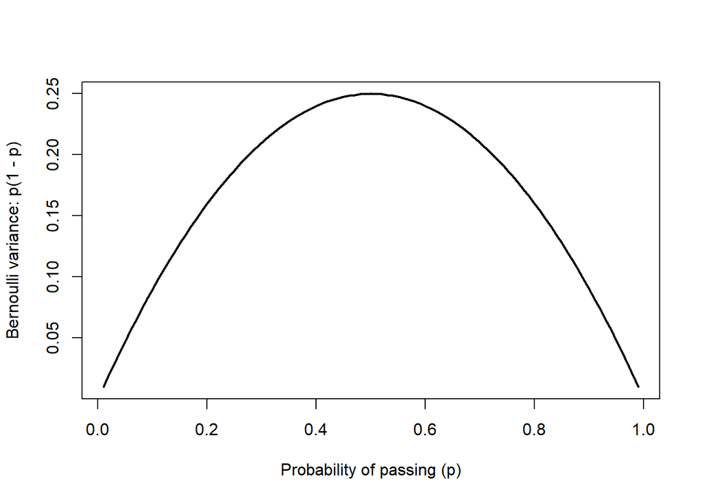

**Code**

```r
p <- seq(0.01, 0.99, by = 0.01)
plot(p, p * (1 - p), type = "l", lwd = 2,
     xlab = "Probability of passing (p)",
     ylab = "Bernoulli variance: p(1 - p)")
```

- Continue

## 3.3 Generalised linear models

A **generalised linear model** (GLM) has three pieces:

1. A distribution for the outcome.
2. A linear predictor.
3. A link function connecting the expected outcome to the linear predictor.

For linear regression, these pieces are:

$$Y_i \sim N(\mu_i, \sigma^2),
\qquad
\mu_i = \eta_i,
\qquad
\eta_i = \beta_0 + \beta_1 X_i.$$

The link is the identity link because the mean itself is modelled directly by the linear predictor.

For logistic regression, the pieces are:

$$Y_i \sim \text{Bernoulli}(p_i),
\qquad
\text{logit}(p_i) = \eta_i,
\qquad
\eta_i = \beta_0 + \beta_1 X_i.$$

The linear predictor is still linear. What changes is the outcome distribution and the link function.

| Component | Linear regression | Logistic regression |
| --- | --- | --- |
| Outcome | Continuous $Y_i$ | Binary $Y_i \in \{0,1\}$ |
| Distribution | Normal | Bernoulli / binomial |
| Mean | $\mu_i = E[Y_i]$ | $p_i = E[Y_i] = P(Y_i=1)$ |
| Link | Identity: $\mu_i = \eta_i$ | Logit: $\log(p_i/(1-p_i)) = \eta_i$ |
| Linear predictor | $\eta_i = \beta_0 + \beta_1 X_i$ | $\eta_i = \beta_0 + \beta_1 X_i$ |
| R function | `lm()` | `glm(..., family = binomial)` |

**Key-point**

Logistic regression is not “nonlinear regression” in the usual sense. It is a linear model for the log-odds, paired with a Bernoulli/binomial error model and a logistic back-transformation to probabilities.

- Continue

## 3.4 The logistic regression model

For the student example with study time as the predictor, the logistic regression model is

$$Y_i \sim \text{Bernoulli}(p_i)$$

and

$$\text{logit}(p_i) = \beta_0 + \beta_1 \text{studytime}_i.$$

To return to the probability scale, we use the logistic function:

$$p_i = \frac{1}{1 + e^{-(\beta_0 + \beta_1 \text{studytime}_i)}}.$$

In R, the inverse-logit transformation is `plogis()`.

**Plot**

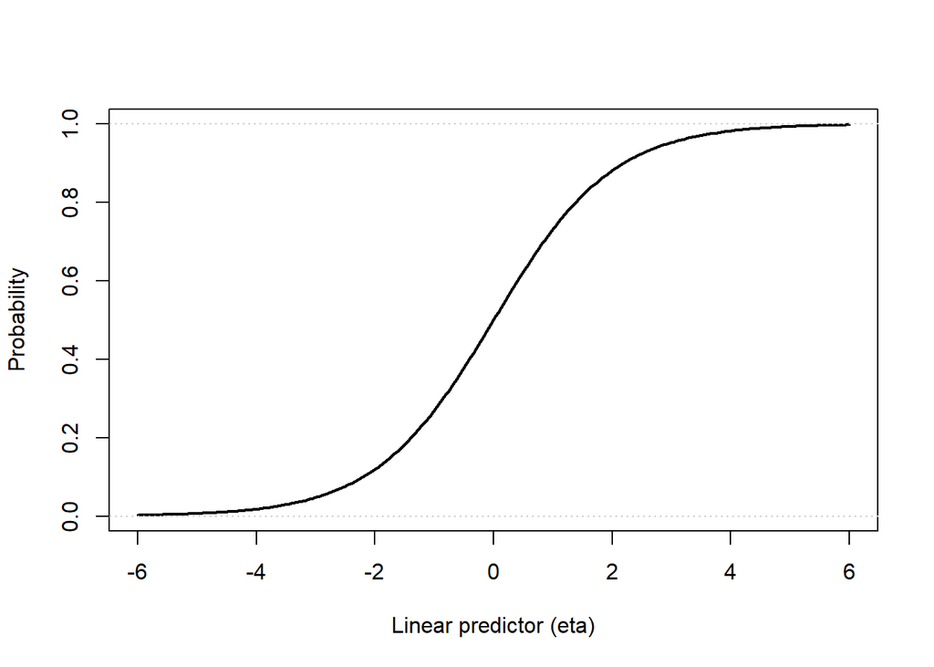

**Code**

```r
eta <- seq(-6, 6, length.out = 200)
plot(eta, plogis(eta), type = "l", lwd = 2,
     xlab = "Linear predictor (eta)",
     ylab = "Probability")
abline(h = c(0, 1), col = "grey80", lty = 3)
```

The curve is S-shaped on the probability scale, but the model is still straight on the log-odds scale.

- Continue

## 3.5 The formula in R

The R formula looks almost the same as the formula for `lm()`:

**Output**

```
Call:
glm(formula = pass_exam ~ studytime, family = binomial, data = students)

Coefficients:
            Estimate Std. Error z value Pr(>|z|)
(Intercept)   0.3222     0.2818   1.143    0.253
studytime     0.1939     0.1311   1.479    0.139

(Dispersion parameter for binomial family taken to be 1)

    Null deviance: 500.50  on 394  degrees of freedom
Residual deviance: 498.27  on 393  degrees of freedom
AIC: 502.27

Number of Fisher Scoring iterations: 4
```

**Code**

```r
fit_study <- glm(pass_exam ~ studytime,
                 data = students,
                 family = binomial)
summary(fit_study)
```

The formula `pass_exam ~ studytime` gives the linear predictor:

$$\eta_i = \beta_0 + \beta_1 \text{studytime}_i.$$

The argument `family = binomial` tells R to use the Bernoulli/binomial error model with the logit link. So the single `glm()` call contains the two changes we need for binary outcomes: a different error model and a different link.

**Note**

The default link for `family = binomial` is the logit link. Writing `family = binomial(link = "logit")` is equivalent, but more explicit.

## 3.6 Chapter summary

Logistic regression follows the same modelling logic as linear regression:

1. Choose an outcome model.
2. Choose a linear predictor.
3. Estimate the unknown coefficients from data.
4. Use the fitted model for interpretation, prediction, and model checking.

The difference is that binary outcomes need a Bernoulli/binomial error model and a logit link. The next chapter focuses on step 3: how `glm()` estimates the coefficients and how to read the fitted model.